# Työ 2

*Describe the work you have done this week and summarize your learning.*

- Describe your work and results clearly.
- Assume the reader has an introductory course level understanding of writing and reading R code as well as statistical methods.
- Assume the reader has no previous knowledge of your data or the more advanced methods you are using.

# Toinen harjoitus

**DATA tuonti**

```r
data <- read.csv("learing_2019.csv")

#Summary
summary(data)
```

```
##        X          gender       Age           Attitude         Points
##  Min.   :  1.00   F:110   Min.   :17.00   Min.   :14.00   Min.   : 7.00
##  1st Qu.: 42.25   M: 56   1st Qu.:21.00   1st Qu.:26.00   1st Qu.:19.00
##  Median : 83.50           Median :22.00   Median :32.00   Median :23.00
##  Mean   : 83.50           Mean   :25.51   Mean   :31.43   Mean   :22.72
##  3rd Qu.:124.75           3rd Qu.:27.00   3rd Qu.:37.00   3rd Qu.:27.75
##  Max.   :166.00           Max.   :55.00   Max.   :50.00   Max.   :33.00
##       Deep            Stra            Surf
##  Min.   :1.583   Min.   :1.250   Min.   :1.583
##  1st Qu.:3.333   1st Qu.:2.625   1st Qu.:2.417
##  Median :3.667   Median :3.188   Median :2.833
##  Mean   :3.680   Mean   :3.121   Mean   :2.787
##  3rd Qu.:4.083   3rd Qu.:3.625   3rd Qu.:3.167
##  Max.   :4.917   Max.   :5.000   Max.   :4.333
```

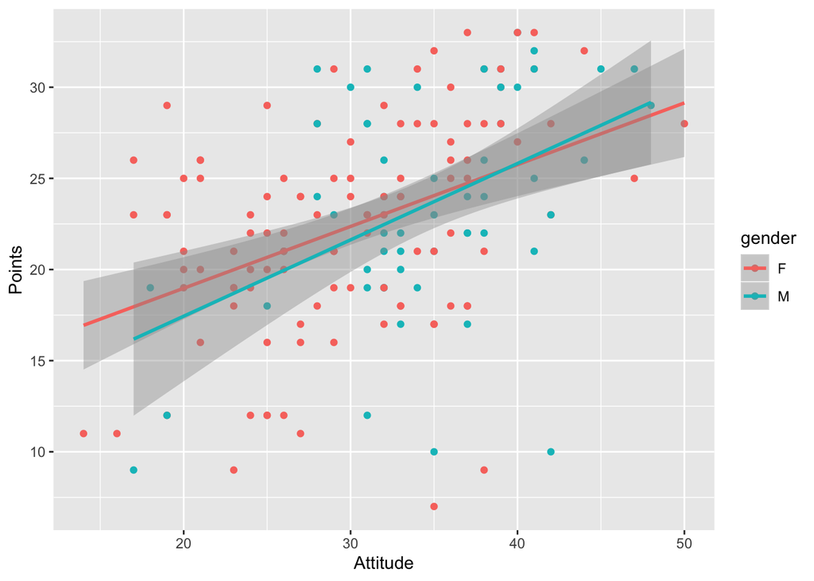

```r
#Access ggplot and GGally
library(ggplot2)

library(GGally)
#Creating graphics
p1 <- ggplot(data, aes(x = Attitude, y = Points, col = gender))

#and fitting linear model
p2 <- p1 + geom_point() + geom_smooth(method = "lm")
p2
```

In these graphs we can see that gender plays a role. Biggest difference between genders seems to be on variable attitude, where females have a clearly lower mean. The distributions of the attitude and surf variables differ between males and females.

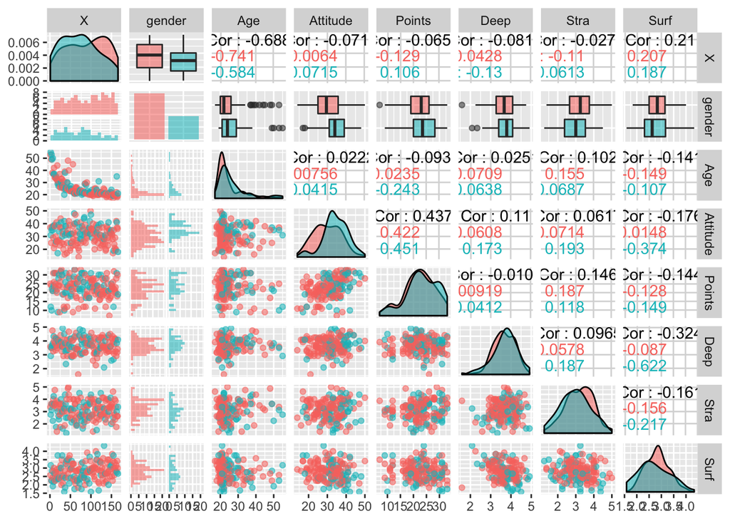

```r
#Correlations

p <- ggpairs(data, mapping = aes(col = gender, alpha = 0.3), lower = list(combo = wrap("facethist", bins = 20)))
p
```

```r
## Regression model with multible explanatory variables
my_model <- lm(Points ~ Attitude + Stra + Surf, data = data)

# Summary of the model
summary(my_model)
```

```
##
## Call:
## lm(formula = Points ~ Attitude + Stra + Surf, data = data)
##
## Residuals:
##      Min       1Q   Median       3Q      Max
## -17.1550  -3.4346   0.5156   3.6401  10.8952
##
## Coefficients:
##             Estimate Std. Error t value Pr(>|t|)
## (Intercept) 11.01711    3.68375   2.991  0.00322 **
## Attitude     0.33952    0.05741   5.913 1.93e-08 ***
## Stra         0.85313    0.54159   1.575  0.11716
## Surf        -0.58607    0.80138  -0.731  0.46563
## ---
## Signif. codes:  0 '***' 0.001 '**' 0.01 '*' 0.05 '.' 0.1 ' ' 1
##
## Residual standard error: 5.296 on 162 degrees of freedom
## Multiple R-squared:  0.2074, Adjusted R-squared:  0.1927
## F-statistic: 14.13 on 3 and 162 DF,  p-value: 3.156e-08
```

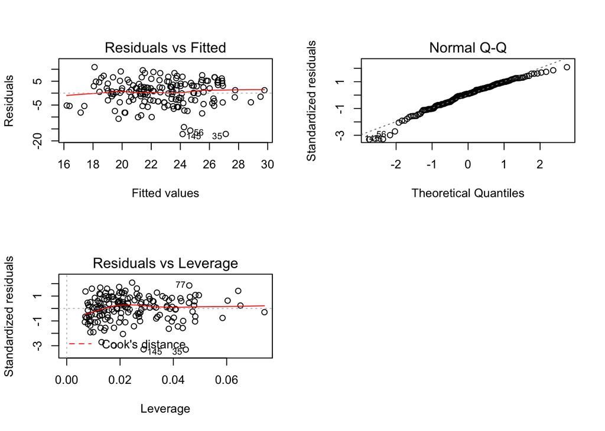

```r
# drawing diagnostic plots using the plot() function. Residuals vs Fitted values, Normal QQ-plot and Residuals vs Leverage.

par(mfrow = c(2,2))
plot(my_model, which = c(1,2,5))
```

The assumptions of the model are that the error terms are approximately normally distributed with mean 0 and identical variation, uncorrelated and independent of the variable of interest. Specifically, the size of the error should not depend on the value of the explanatory or interesting variables.

From these pictures it seems that the model assumptions are approximately correct, with the small exception of small and large values of Points corresponding to some larger deviation from the estimated mean. Also, a couple of observations seem to have somewhat large leverages, but overall the assumptions of the model seem to hold quite well. Questionable is the ends of the spectrum, and additional analysis is needed.